# Introduction_Dplyr

## Libraries

```r
library(dplyr)
library(hflights)
```

## `data.frame` to `tbl`

tbl_df is a wrapper for df to print the obj fits into the console window. The tbl object inherits data.frame object, therefore, any methods from data.frame is applicable for tbl object

```r
hflights <- tbl_df(hflights)
hflights
```

```
## Source: local data frame [227,496 x 21]
##
##    Year Month DayofMonth DayOfWeek DepTime ArrTime UniqueCarrier FlightNum
## 1  2011     1          1         6    1400    1500            AA       428
## 2  2011     1          2         7    1401    1501            AA       428
## 3  2011     1          3         1    1352    1502            AA       428
## 4  2011     1          4         2    1403    1513            AA       428
## 5  2011     1          5         3    1405    1507            AA       428
## 6  2011     1          6         4    1359    1503            AA       428
## 7  2011     1          7         5    1359    1509            AA       428
## 8  2011     1          8         6    1355    1454            AA       428
## 9  2011     1          9         7    1443    1554            AA       428
## 10 2011     1         10         1    1443    1553            AA       428
## ..  ...   ...        ...       ...     ...     ...           ...       ...
## Variables not shown: TailNum (chr), ActualElapsedTime (int), AirTime
##   (int), ArrDelay (int), DepDelay (int), Origin (chr), Dest (chr),
##   Distance (int), TaxiIn (int), TaxiOut (int), Cancelled (int),
##   CancellationCode (chr), Diverted (int)
```

```r
# get the structure of the data
glimpse(hflights)
```

```
## Variables:
## $ Year              (int) 2011, 2011, 2011, 2011, 2011, 2011, 2011, 20...
## $ Month             (int) 1, 1, 1, 1, 1, 1, 1, 1, 1, 1, 1, 1, 1, 1, 1,...
## $ DayofMonth        (int) 1, 2, 3, 4, 5, 6, 7, 8, 9, 10, 11, 12, 13, 1...
## $ DayOfWeek         (int) 6, 7, 1, 2, 3, 4, 5, 6, 7, 1, 2, 3, 4, 5, 6,...
## $ DepTime           (int) 1400, 1401, 1352, 1403, 1405, 1359, 1359, 13...
## $ ArrTime           (int) 1500, 1501, 1502, 1513, 1507, 1503, 1509, 14...
## $ UniqueCarrier     (chr) "AA", "AA", "AA", "AA", "AA", "AA", "AA", "A...
## $ FlightNum         (int) 428, 428, 428, 428, 428, 428, 428, 428, 428,...
## $ TailNum           (chr) "N576AA", "N557AA", "N541AA", "N403AA", "N49...
## $ ActualElapsedTime (int) 60, 60, 70, 70, 62, 64, 70, 59, 71, 70, 70, ...
## $ AirTime           (int) 40, 45, 48, 39, 44, 45, 43, 40, 41, 45, 42, ...
## $ ArrDelay          (int) -10, -9, -8, 3, -3, -7, -1, -16, 44, 43, 29,...
## $ DepDelay          (int) 0, 1, -8, 3, 5, -1, -1, -5, 43, 43, 29, 19, ...
## $ Origin            (chr) "IAH", "IAH", "IAH", "IAH", "IAH", "IAH", "I...
## $ Dest              (chr) "DFW", "DFW", "DFW", "DFW", "DFW", "DFW", "D...
## $ Distance          (int) 224, 224, 224, 224, 224, 224, 224, 224, 224,...
## $ TaxiIn            (int) 7, 6, 5, 9, 9, 6, 12, 7, 8, 6, 8, 4, 6, 5, 6...
## $ TaxiOut           (int) 13, 9, 17, 22, 9, 13, 15, 12, 22, 19, 20, 11...
## $ Cancelled         (int) 0, 0, 0, 0, 0, 0, 0, 0, 0, 0, 0, 0, 0, 0, 0,...
## $ CancellationCode  (chr) "", "", "", "", "", "", "", "", "", "", "", ...
## $ Diverted          (int) 0, 0, 0, 0, 0, 0, 0, 0, 0, 0, 0, 0, 0, 0, 0,...
```

```r
class(hflights)
```

```
## [1] "tbl_df"     "tbl"        "data.frame"
```

## `Lookup vector`

Look up vector is the named atomic vector

```r
# convert the flight code into its name
lut <- c("AA" = "American", "AS" = "Alaska", "B6" = "JetBlue", "CO" = "Continental", "DL" = "Delta", "OO" = "SkyWest", "UA" = "United", "US" = "US_Airways", "WN" = "Southwest", "EV" = "Atlantic_Southeast", "F9" = "Frontier", "FL" = "AirTran", "MQ" = "American_Eagle", "XE" = "ExpressJet", "YV" = "Mesa")
hflights$UniqueCarrier <- lut[hflights$UniqueCarrier]
glimpse(hflights)
```

```
## Variables:
## $ Year              (int) 2011, 2011, 2011, 2011, 2011, 2011, 2011, 20...
## $ Month             (int) 1, 1, 1, 1, 1, 1, 1, 1, 1, 1, 1, 1, 1, 1, 1,...
## $ DayofMonth        (int) 1, 2, 3, 4, 5, 6, 7, 8, 9, 10, 11, 12, 13, 1...
## $ DayOfWeek         (int) 6, 7, 1, 2, 3, 4, 5, 6, 7, 1, 2, 3, 4, 5, 6,...
## $ DepTime           (int) 1400, 1401, 1352, 1403, 1405, 1359, 1359, 13...
## $ ArrTime           (int) 1500, 1501, 1502, 1513, 1507, 1503, 1509, 14...
## $ UniqueCarrier     (chr) "American", "American", "American", "America...
## $ FlightNum         (int) 428, 428, 428, 428, 428, 428, 428, 428, 428,...
## $ TailNum           (chr) "N576AA", "N557AA", "N541AA", "N403AA", "N49...
## $ ActualElapsedTime (int) 60, 60, 70, 70, 62, 64, 70, 59, 71, 70, 70, ...
## $ AirTime           (int) 40, 45, 48, 39, 44, 45, 43, 40, 41, 45, 42, ...
## $ ArrDelay          (int) -10, -9, -8, 3, -3, -7, -1, -16, 44, 43, 29,...
## $ DepDelay          (int) 0, 1, -8, 3, 5, -1, -1, -5, 43, 43, 29, 19, ...
## $ Origin            (chr) "IAH", "IAH", "IAH", "IAH", "IAH", "IAH", "I...
## $ Dest              (chr) "DFW", "DFW", "DFW", "DFW", "DFW", "DFW", "D...
## $ Distance          (int) 224, 224, 224, 224, 224, 224, 224, 224, 224,...
## $ TaxiIn            (int) 7, 6, 5, 9, 9, 6, 12, 7, 8, 6, 8, 4, 6, 5, 6...
## $ TaxiOut           (int) 13, 9, 17, 22, 9, 13, 15, 12, 22, 19, 20, 11...
## $ Cancelled         (int) 0, 0, 0, 0, 0, 0, 0, 0, 0, 0, 0, 0, 0, 0, 0,...
## $ CancellationCode  (chr) "", "", "", "", "", "", "", "", "", "", "", ...
## $ Diverted          (int) 0, 0, 0, 0, 0, 0, 0, 0, 0, 0, 0, 0, 0, 0, 0,...
```

```r
# Build the lookup table for the cancellation code
lut <- c("A" = "carrier", "B" = "weather", "C" = "FFA", "D" = "security", "E"="not cancelled")

# change the empty code into E code for empty
hflights$CancellationCode[hflights$CancellationCode == ""] <- "E"

# map it
hflights$CancellationCode <- lut[hflights$CancellationCode]

# Inspect the resulting raw values of your variables
glimpse(hflights)
```

```
## Variables:
## $ Year              (int) 2011, 2011, 2011, 2011, 2011, 2011, 2011, 20...
## $ Month             (int) 1, 1, 1, 1, 1, 1, 1, 1, 1, 1, 1, 1, 1, 1, 1,...
## $ DayofMonth        (int) 1, 2, 3, 4, 5, 6, 7, 8, 9, 10, 11, 12, 13, 1...
## $ DayOfWeek         (int) 6, 7, 1, 2, 3, 4, 5, 6, 7, 1, 2, 3, 4, 5, 6,...
## $ DepTime           (int) 1400, 1401, 1352, 1403, 1405, 1359, 1359, 13...
## $ ArrTime           (int) 1500, 1501, 1502, 1513, 1507, 1503, 1509, 14...
## $ UniqueCarrier     (chr) "American", "American", "American", "America...
## $ FlightNum         (int) 428, 428, 428, 428, 428, 428, 428, 428, 428,...
## $ TailNum           (chr) "N576AA", "N557AA", "N541AA", "N403AA", "N49...
## $ ActualElapsedTime (int) 60, 60, 70, 70, 62, 64, 70, 59, 71, 70, 70, ...
## $ AirTime           (int) 40, 45, 48, 39, 44, 45, 43, 40, 41, 45, 42, ...
## $ ArrDelay          (int) -10, -9, -8, 3, -3, -7, -1, -16, 44, 43, 29,...
## $ DepDelay          (int) 0, 1, -8, 3, 5, -1, -1, -5, 43, 43, 29, 19, ...
## $ Origin            (chr) "IAH", "IAH", "IAH", "IAH", "IAH", "IAH", "I...
## $ Dest              (chr) "DFW", "DFW", "DFW", "DFW", "DFW", "DFW", "D...
## $ Distance          (int) 224, 224, 224, 224, 224, 224, 224, 224, 224,...
## $ TaxiIn            (int) 7, 6, 5, 9, 9, 6, 12, 7, 8, 6, 8, 4, 6, 5, 6...
## $ TaxiOut           (int) 13, 9, 17, 22, 9, 13, 15, 12, 22, 19, 20, 11...
## $ Cancelled         (int) 0, 0, 0, 0, 0, 0, 0, 0, 0, 0, 0, 0, 0, 0, 0,...
## $ CancellationCode  (chr) "not cancelled", "not cancelled", "not cance...
## $ Diverted          (int) 0, 0, 0, 0, 0, 0, 0, 0, 0, 0, 0, 0, 0, 0, 0,...
```

## Grammar of dplyr

- `select` (column selection)
- `mutate` (new column creation)
- `filter` (row removal)
- `arrange` (row reordering according to single or multiple variables)
- `summarize` (summary stats)

Common organization of the data is to all observations into rows and variables into columns. This data organization is so called tidy data, referred to `tidyr`

`select` and `mutate` are for variables manipulation

`filter` and `arrange` are for observation manipulaton

`summarize` is for group of observation manipulation

## Question: Do delay tend to shrink or grow during the course of the flight?

```r
# 4 variables are used here: ActualElapsedTime, AirTime, ArrDelay, DepDelay

# a new copy of hflights without modification of its original hflights
h1 <- select(hflights, ActualElapsedTime, AirTime, ArrDelay, DepDelay)
h2 <- mutate(h1, loss= ArrDelay - DepDelay)

# loss if positive means that the plane lose time during the flight
# loss if negative means that the plane makes up time and becomes less delay
mean(h2$loss, na.rm = T)
```

```
## [1] -2.320649
```

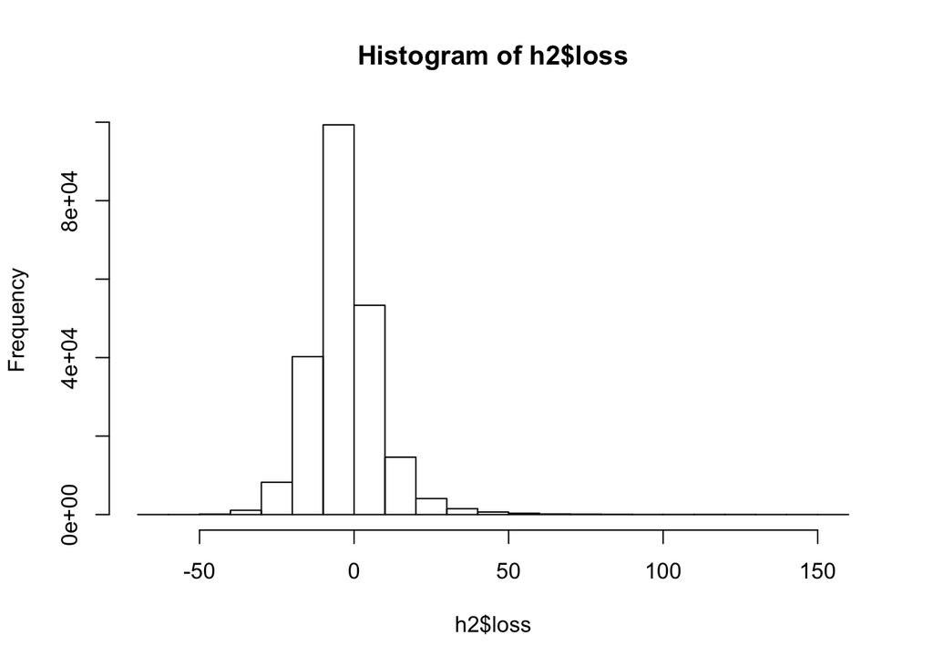

```r
hist(h2$loss)
```

```r
median(h2$loss, na.rm=T)
```

```
## [1] -3
```

The negative loss means that delays tend to shrink in the course of the flight. ## Wrapper function inside select

dplyr provides 6 helper functions, each of which only works when used inside select().

- `starts_with("X")`: every name that starts with “X”,
- `ends_with("X")`: every name that ends with “X”,
- `contains("X")`: every name that contains “X”,
- `matches("X")`: every name that matches “X”, which can be a regular expression,
- `num_range("x", 1:5)`: the variables named x01, x02, x03, x04 and x05,
- `one_of(x)`: every name that appears in x, which should be a character vector.

```r
# Return a tbl containing just ArrDelay and DepDelay
select(hflights, contains("Delay"))
```

```
## Source: local data frame [227,496 x 2]
##
##    ArrDelay DepDelay
## 1       -10        0
## 2        -9        1
## 3        -8       -8
## 4         3        3
## 5        -3        5
## 6        -7       -1
## 7        -1       -1
## 8       -16       -5
## 9        44       43
## 10       43       43
## ..      ...      ...
```

```r
# Return a tbl as described in the second exercise, using both helper functions and variable names
select(hflights, UniqueCarrier, ends_with("Num"), contains("Cancell"))
```

```
## Source: local data frame [227,496 x 5]
##
##    UniqueCarrier FlightNum TailNum Cancelled CancellationCode
## 1       American       428  N576AA         0    not cancelled
## 2       American       428  N557AA         0    not cancelled
## 3       American       428  N541AA         0    not cancelled
## 4       American       428  N403AA         0    not cancelled
## 5       American       428  N492AA         0    not cancelled
## 6       American       428  N262AA         0    not cancelled
## 7       American       428  N493AA         0    not cancelled
## 8       American       428  N477AA         0    not cancelled
## 9       American       428  N476AA         0    not cancelled
## 10      American       428  N504AA         0    not cancelled
## ..           ...       ...     ...       ...              ...
```

```r
# Return a tbl as described in the third exercise, using only helper functions.
select(hflights, contains("Time"), contains("Delay"))
```

```
## Source: local data frame [227,496 x 6]
##
##    DepTime ArrTime ActualElapsedTime AirTime ArrDelay DepDelay
## 1     1400    1500                60      40      -10        0
## 2     1401    1501                60      45       -9        1
## 3     1352    1502                70      48       -8       -8
## 4     1403    1513                70      39        3        3
## 5     1405    1507                62      44       -3        5
## 6     1359    1503                64      45       -7       -1
## 7     1359    1509                70      43       -1       -1
## 8     1355    1454                59      40      -16       -5
## 9     1443    1554                71      41       44       43
## 10    1443    1553                70      45       43       43
## ..     ...     ...               ...     ...      ...      ...
```

## Filter

### R logical operator to be used in `filter`

x < y, TRUE if x is less than y x <= y, TRUE if x is less than or equal to y x == y, TRUE if x equals y x != y, TRUE if x does not equal y x >= y, TRUE if x is greater than or equal to y x > y, TRUE if x is greater than y x %in% c(a, b, c), TRUE if x is in the vector c(a, b, c)

Question:How many weekend flights flew a distance of more than 1000 miles but had a total taxiing time below 15 minutes?

```r
filter(hflights, DayOfWeek %in% c(6,7) & Distance > 1000 & (TaxiIn + TaxiOut )< 15)
```

```
## Source: local data frame [1,739 x 21]
##
##    Year Month DayofMonth DayOfWeek DepTime ArrTime UniqueCarrier FlightNum
## 1  2011     1         23         7    1535    1933       JetBlue       624
## 2  2011     1         30         7     851    1230   Continental      1058
## 3  2011     1         30         7    2234       2   Continental      1717
## 4  2011     1         29         6    1220    1353   Continental      1620
## 5  2011     1         23         7     847    1213   Continental      1058
## 6  2011     1         23         7    1224    1345   Continental      1629
## 7  2011     1         23         7     931    1045   Continental      1723
## 8  2011     1         22         6     942    1340   Continental         1
## 9  2011     1         16         7     848    1136   Continental       309
## 10 2011     1         16         7    1030    1406   Continental       358
## ..  ...   ...        ...       ...     ...     ...           ...       ...
## Variables not shown: TailNum (chr), ActualElapsedTime (int), AirTime
##   (int), ArrDelay (int), DepDelay (int), Origin (chr), Dest (chr),
##   Distance (int), TaxiIn (int), TaxiOut (int), Cancelled (int),
##   CancellationCode (chr), Diverted (int)
```

## Arrange

By default, arrange() arranges the rows from smallest to largest. Rows with the smallest value of the variable will appear at the top of the data set. You can reverse this behavior with the desc() function. arrange() will reorder the rows from largest to smallest values of a variable if you wrap the variable name in desc() before passing it to arrange().

## Summarise

`summarise` works like `mutate` though, it does not copy dataset but returns the summary rows.

```r
# Determine the shortest and longest distance flown and save statistics to min_dist and max_dist resp.
s1 <- summarise(hflights, min_dist = min(Distance), max_dist = max(Distance))
```

### Aggregating functions

`summarise` takes the aggregating functions. Here are the commonly used :

- `min(x)` - minimum value of vector x.
- `max(x)` - maximum value of vector x.
- `mean(x)` - mean value of vector x.
- `median(x)` - median value of vector x.
- `quantile(x, p)` - pth quantile of vector x.
- `sd(x)` - standard deviation of vector x.
- `var(x)` - variance of vector x.
- `IQR(x)` - Inter Quartile Range (IQR) of vector x.
- `diff(range(x))` - total range of vector x.
- `first(x)` - The first element of vector x.
- `last(x)` - The last element of vector x.
- `nth(x, n)` - The nth element of vector x.
- `n()` - The number of rows in the data.frame or group of observations that summarise() describes.
- `n_distinct(x)` - The number of unique values in vector x.

Next to these dplyr-specific functions, you can also turn a logical test into an aggregating function with `sum()` or `mean()`. A logical test returns a vector of TRUE’s and FALSE’s. When you apply `sum()` or `mean()` to such a vector, R coerces each TRUE to a 1 and each FALSE to a 0. This allows you to find the total number or proportion of observations that passed the test, respectively.

```r
# Calculate the summarizing statistics for flights flown by American Airlines (carrier code "American")
aa <- filter(hflights, UniqueCarrier == "American")
s2 <- summarise(aa, n_flights = n(), n_canc = sum(Cancelled), p_canc = n_canc/n_flights * 100, avg_delay = mean(ArrDelay, na.rm=T))
```

## Piping or Chaining Functions

Piping `%>%`, works as `obj %>% func(x)`, e.g

```r
c(1,2,3) %>% sum
```

```
## [1] 6
```

Question: Drive or fly?

```r
#Let's define preferable flights as flights that are 150% faster than driving, i.e. that travel 105 mph or greater in real time. Also, assume that cancelled or diverted flights are less preferable than driving.
# Solve the exercise using a combination of dplyr verbs and %>%
hflights %>%
  select(Dest, Cancelled, Distance, ActualElapsedTime, Diverted) %>%
  mutate(RealTime = ActualElapsedTime + 100, mph = Distance / RealTime * 60) %>%
  filter(mph < 105 | Diverted == 1 | Cancelled == 1) %>%
  summarise(n_non = n(), p_non = n_non/nrow(hflights)*100,
            n_dest = n_distinct(Dest), min_dist = min(Distance), max_dist = max(Distance))
```

```
## Source: local data frame [1 x 5]
##
##   n_non    p_non n_dest min_dist max_dist
## 1 42400 18.63769    113       79     3904
```

## Group-by

```r
# hflights is in the workspace as a tbl, with translated carrier names

# Make the calculations to end up with ordered statistics per carrier
hflights %>%
    group_by(UniqueCarrier) %>%
    summarise(n_flights = n(),
              n_canc = sum(Cancelled == 1),
              p_canc = n_canc/n_flights * 100,
              avg_delay = mean(ArrDelay, na.rm=T)) %>%
    arrange(avg_delay, p_canc)
```

```
## Source: local data frame [15 x 5]
##
##         UniqueCarrier n_flights n_canc    p_canc  avg_delay
## 1          US_Airways      4082     46 1.1268986 -0.6307692
## 2            American      3244     60 1.8495684  0.8917558
## 3             AirTran      2139     21 0.9817672  1.8536239
## 4              Alaska       365      0 0.0000000  3.1923077
## 5                Mesa        79      1 1.2658228  4.0128205
## 6               Delta      2641     42 1.5903067  6.0841374
## 7         Continental     70032    475 0.6782614  6.0986983
## 8      American_Eagle      4648    135 2.9044750  7.1529751
## 9  Atlantic_Southeast      2204     76 3.4482759  7.2569543
## 10          Southwest     45343    703 1.5504047  7.5871430
## 11           Frontier       838      6 0.7159905  7.6682692
## 12         ExpressJet     73053   1132 1.5495599  8.1865242
## 13            SkyWest     16061    224 1.3946828  8.6934922
## 14            JetBlue       695     18 2.5899281  9.8588410
## 15             United      2072     34 1.6409266 10.4628628
```

```r
# Answer the question: At which day of the week is total taxiing time highest?
hflights %>%
    group_by(DayOfWeek) %>%
    summarise(avg_taxi = mean((TaxiIn + TaxiOut), na.rm=T)) %>%
    arrange(desc(avg_taxi))
```

```
## Source: local data frame [7 x 2]
##
##   DayOfWeek avg_taxi
## 1         1 21.77027
## 2         2 21.43505
## 3         4 21.26076
## 4         3 21.19055
## 5         5 21.15805
## 6         7 20.93726
## 7         6 20.43061
```

### group-by with mutate rank function

You can also combine `group_by()` with `mutate()`. When you mutate grouped data, `mutate()` will calculate the new variables independently for each group. This is particularly useful when `mutate()` uses the `rank()` function, which calculates within group rankings. `rank()` takes a group of values and calculates the rank of each value within the group, e.g. `rank(c(21, 22, 24, 23))` has output `[1] 1 2 4 3.`

```r
#Use group_by() and summarise() to compare the individual carriers. For each carrier, count the total number of flights flown by the carrier (n_flights), the total number of cancelled flights (n_canc), the percentage of cancelled flights (p_canc), and the average arrival delay of the flights whose delay does not equal NA (avg_delay). Once you've calculated these results, arrange() the carriers from low to high by their average arrival delay. Use percentage of flights cancelled to break any ties. Which airline scores best based on these statistics?
#Come up with a way to answer this question: At which day of the week is the average total taxiing time highest? Use group_by(), summarise() and arrange(); you should avoid the use of mutate(). Define the grouped average total taxiing time to be avg_taxi.
# dplyr is loaded, hflights is loaded with fancy carrier names

# Solution to first instruction
hflights %>%
    filter(!is.na(ArrDelay)) %>%
    group_by(UniqueCarrier) %>%
    summarise(p_delay = sum(ArrDelay > 0)/ n()) %>%
    mutate(rank = rank(p_delay)) %>%
    arrange(rank)
```

```
## Source: local data frame [15 x 3]
##
##         UniqueCarrier   p_delay rank
## 1            American 0.3030208    1
## 2             AirTran 0.3112269    2
## 3          US_Airways 0.3267990    3
## 4  Atlantic_Southeast 0.3677511    4
## 5      American_Eagle 0.3696714    5
## 6               Delta 0.3871092    6
## 7             JetBlue 0.3952452    7
## 8              Alaska 0.4368132    8
## 9           Southwest 0.4644557    9
## 10               Mesa 0.4743590   10
## 11        Continental 0.4907385   11
## 12         ExpressJet 0.4943420   12
## 13             United 0.4963109   13
## 14            SkyWest 0.5350105   14
## 15           Frontier 0.5564904   15
```

```r
# Solution to second instruction
hflights %>%
    filter(!is.na(ArrDelay), ArrDelay > 0) %>%
    group_by(UniqueCarrier) %>%
    summarise(avg = mean(ArrDelay, na.rm = T)) %>%
    mutate(rank = rank(avg)) %>%
    arrange(rank)
```

```
## Source: local data frame [15 x 3]
##
##         UniqueCarrier      avg rank
## 1                Mesa 18.67568    1
## 2            Frontier 18.68683    2
## 3          US_Airways 20.70235    3
## 4         Continental 22.13374    4
## 5              Alaska 22.91195    5
## 6             SkyWest 24.14663    6
## 7          ExpressJet 24.19337    7
## 8           Southwest 25.27750    8
## 9             AirTran 27.85693    9
## 10           American 28.49740   10
## 11              Delta 32.12463   11
## 12             United 32.48067   12
## 13     American_Eagle 38.75135   13
## 14 Atlantic_Southeast 40.24231   14
## 15            JetBlue 45.47744   15
```